# DataViz Makeover 1

In this post, we present the Labour Force data using Tableau.

Farah Foo https://sg.linkedin.com/in/farahfoo (SMU Masters in IT business (Fintech and Analytics))https://scis.smu.edu.sg/master-it-business  
2022-02-12

# 1. Critique of Visualisation

The data visualisation is created by using data provided by Ministrty of Manpower, Singapore (MOM). The data are available under the page entitle [Statistical Table: Labour Force](https://stats.mom.gov.sg/Pages/LabourForceTimeSeries.aspx).

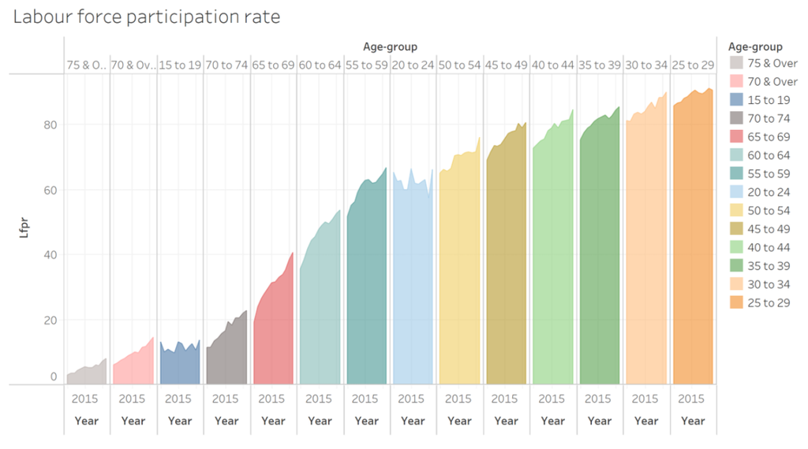

Labour force participation rate

## 1a. Clarity

- The order of the age group at the top of the chart is not sorted in ascending or descending order. This makes the graph hard to read. It is also misleading the readers to think there is an increasing trend.
- The Y-axis is labelled as “Lfpr” which cannot be understood by readers.
- There should be an indication / label that the numbers on the Y-axis is referring to percentage points and not absolute number.
- There are faint horizontal lines at the 20, 40, 60, 80 levels of the Y-axis. While it helps readers to read across the chart, the chart should have indicated these horizontal lines clearer according to the level that the write wants to highlight.

## 1c. Accuracy

- Each age group column is indicated as Year 2015 at the bottom x-axis, however it is clear in each of the Age-group graph that it should have been made up of multiple years since the area charts are increasing.
- Readers are also not able to get much insight into each age group since the area chart is squeezed into a tight column.
- The chart has no data source included, so readers cannot understand the data source to put more context around the graph

# 2. Proposed Design

The initial sketch of the proposed design is as follow. The final chart may have slight differences as imrpovements are made when the visualisation is created in Tableau.

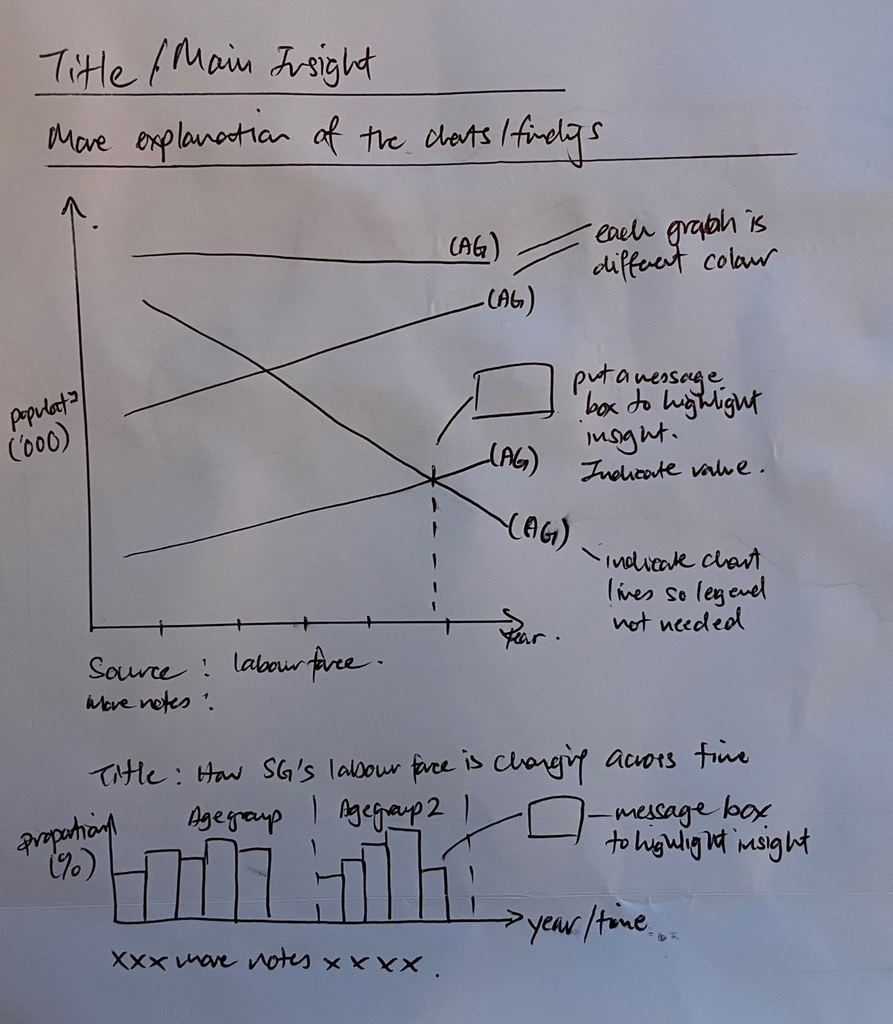

Sketch for revised visualisation

## 2.1 Clarity

- The proposed chart uses a line chart and will show the trend of age groups across the years clearly as it allows for comparison across the age groups, instead of an area chart.
- The Y axis will have a proper name, and the x-axis name will/may be removed since the axis label is inituitive enough
- Any insight will have a clear label on the chart to draw reader’s attention to the main point.
- The second chart at the bottom will focus on showing the proportion of age groups in Singapore so that we can know whether Singapore has a relative aging population.

## 2.2 Aesthetics

- The chart will have a clear, informative title, accompanied with a subtitle for more information. There will also be a caption to indicate the data source so readers know the context.
- We will remove the legend and label the chart directly to reduce clutter
- Values of interesting points will be indicated to readers to get additional information.

## 2.3 Accuracy

- In the proposed design, the x-axis will be correctly indicating the timeline / year for the period, so that readers would be able to see the trending across the years.

# 3. Visualisation on Tableau

# 4. Step-By-Step Preparation

The data is prepared in Tableau software.

**4.1** Load the xls file mrsd_20_Res_labour_force_by_age_sex_28Jan2022 into tableau and Select the option “Cleaned with Data interpreter”.

[figure not shown]

**4.2** Note in the data there are 3 rows of text which we should remove. To remove, select filter function at the top right corner and add a filter. Select the females, males, and total and tick exclude.

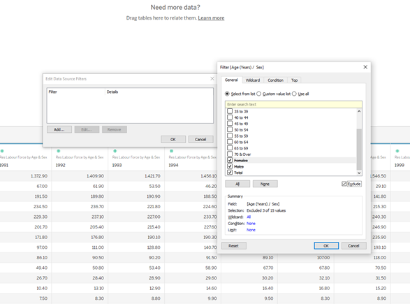

**4.3** Next we only want the rows of data relating to the total population, so we use the Extract function , click edit and then select to extract out the top 12 rows of data only.

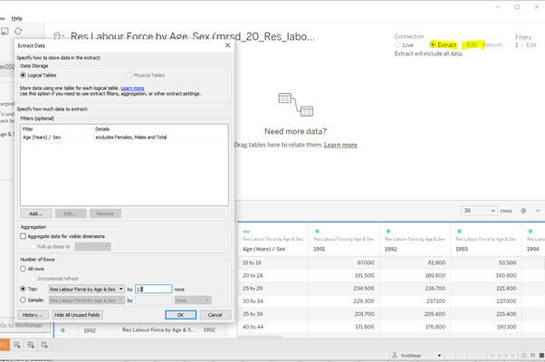

**4.4** The preview in the data source tab shows all the data available in the raw data, hence to check if the data extracted is correct, create a sheet and pull the years to the row and 1991 to the sum data.

Perform a check of a single data (eg. Age 15-19 for year 1991) point back to the raw file to know if the data extracted is correct.

[figure not shown]

**4.5** You can see that Tableau and the raw file reports 67.0 for Age 15-19 for year 1991, hence the extract in tableau is correct.

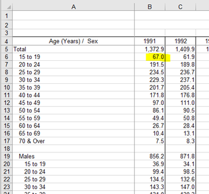

**4.6** Save the file out as mrsd_20_Res_labour_force_by_age_sex_28Jan2022.csv

[figure not shown]

**4.7** Click on add and select text file and load in the created csv file mrsd_20_Res_labour_force_by_age_sex_28Jan2022.csv

[figure not shown]

**4.8** After loading the data, select Connection – Live.

**4.9** You will notice that there is a 2007 and 2007a year. Based on the notes from the data source, 2007a is “ June 2007 data have been adjusted based on latest revised population estimates from the Singapore Department of Statistics to facilitate comparisons with June 2008 onwards.”. We will remove the year 2007 from the data set after pivoting.

Select all the columns of years and right click to select pivot. Pivoting the data will transpose the year into a variable / column.

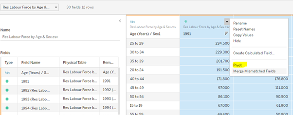

**4.10** The data should look like this after pivoting, with a the year as a column variable.

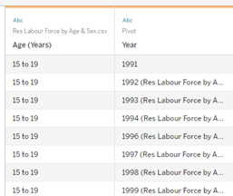

**4.11** Remove the year 2007 from the data set since it is a duplicate set of data. Use the edit function at the top right corner, click add, select 2007 and click exclude.

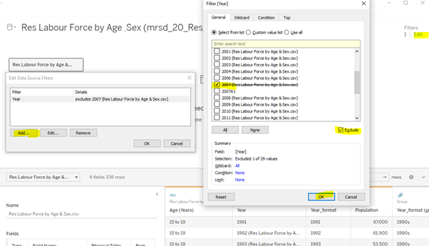

**4.12** To rename the year 2007a to 2007, right click the year column and select calculated field. Write in the if statement. Rename the new column to Year_format.

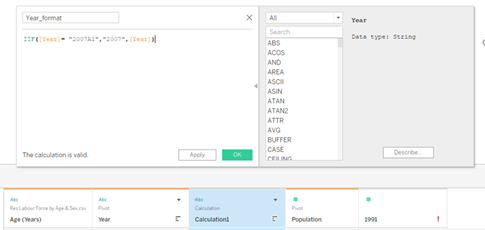

**4.13** Create a new column called “Age Group” to bucket up the Age (years) for easier analysis.

Right click the Age (Years) column and create a group called accordingly. These groups reduces the number of age bands to reduce clutter.

- Young adult (15 – 24),
- Working adult (25 – 39)
- Mid life Worker (40 – 54),
- Retiring (55 – 64),
- Senior (65 – 70 & over)

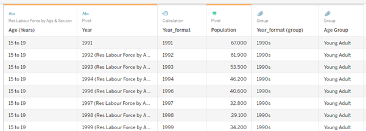

#### The data set is ready for charting!